# Face-to-BMI EDA

This notebook audits the BMI face dataset before feature extraction and fine-tuning. The paper benchmark to beat is the VGG-Face result: Pearson `r = 0.65` overall, `0.71` for male faces, and `0.57` for female faces.

The CSV has an `is_training` column, so this notebook treats `is_training == 1` as train and `is_training == 0` as test. The dataset appears to contain before/after image pairs, but there is no explicit pair column in the CSV, so the notebook infers pairs from the image number: `pair_id = image_index // 2`. The leakage checks below verify whether those inferred pairs stay inside one split.

```python
from pathlib import Path
import hashlib
import math
import warnings
import os

import matplotlib.pyplot as plt
import numpy as np
import pandas as pd
from IPython.display import display
from PIL import Image, ImageOps, ImageStat, UnidentifiedImageError

try:
    import seaborn as sns
    sns.set_theme(style="whitegrid", context="notebook")
except Exception:
    sns = None

try:
    import cv2
except Exception:
    cv2 = None

warnings.filterwarnings("ignore")
pd.set_option("display.max_columns", 80)
pd.set_option("display.width", 160)

ROOT = Path("/Users/satanhaha/Documents/MS ADS/ML2/Final Project")

PROJECT_ROOT = ROOT / "Nyssa"
DATA_DIR = ROOT / "BMI" / "Data"
IMAGE_DIR = DATA_DIR / "Images"
CSV_PATH = DATA_DIR / "data.csv"
OUTPUT_DIR = PROJECT_ROOT / "Nyssa" / "eda_outputs"
OUTPUT_DIR.mkdir(parents=True, exist_ok=True)

BENCHMARKS = {
    "VGG-Net overall Pearson r": 0.47,
    "VGG-Face male Pearson r": 0.71,
    "VGG-Face female Pearson r": 0.57,
    "VGG-Face overall Pearson r": 0.65,
}

CSV_PATH, IMAGE_DIR, OUTPUT_DIR
```

```
(PosixPath('/Users/satanhaha/Documents/MS ADS/ML2/Final Project/BMI/Data/data.csv'),
 PosixPath('/Users/satanhaha/Documents/MS ADS/ML2/Final Project/BMI/Data/Images'),
 PosixPath('/Users/satanhaha/Documents/MS ADS/ML2/Final Project/Nyssa/Nyssa/eda_outputs'))
```

## 1. Load Metadata

```python
df_raw = pd.read_csv(CSV_PATH)
df = df_raw.copy()

if "Unnamed: 0" in df.columns:
    df = df.drop(columns=["Unnamed: 0"])

required_cols = {"bmi", "gender", "is_training", "name"}
missing_cols = required_cols - set(df.columns)
if missing_cols:
    raise ValueError(f"Missing required columns: {sorted(missing_cols)}")

df["image_path"] = df["name"].apply(lambda x: IMAGE_DIR / str(x))
df["split"] = np.where(df["is_training"].astype(int).eq(1), "train", "test")
df["gender"] = df["gender"].astype(str).str.strip()
df["image_index"] = df["name"].astype(str).str.extract(r"(\d+)", expand=False).astype("Int64")
df["pair_id"] = (df["image_index"] // 2).astype("Int64")
df["pair_position"] = np.where(df["image_index"] % 2 == 0, "first_in_pair", "second_in_pair")

# creating bmi bins will help with identifying class imbalance and stratification for train/test splits
# bmi bins from paper
bmi_bins = [0, 18.5, 25, 30, 35, 40, np.inf]
bmi_labels = [
    "underweight",
    "normal",
    "overweight",
    "moderately_obese",
    "severely_obese",
    "very_severely_obese",
]
df["bmi_class"] = pd.cut(df["bmi"], bins=bmi_bins, labels=bmi_labels, right=True, include_lowest=True)

print(f"Rows: {len(df):,}")
print(f"Unique image names: {df['name'].nunique():,}")
print(f"Unique inferred pairs: {df['pair_id'].nunique():,}")
display(df.head())
display(df.dtypes.to_frame("dtype"))
```

```
Rows: 4,206
Unique image names: 4,206
Unique inferred pairs: 2,103
```

|  | bmi | gender | is_training | name | image_path | split | image_index | pair_id | pair_position | bmi_class |
| --- | --- | --- | --- | --- | --- | --- | --- | --- | --- | --- |
| 0 | 34.207396 | Male | 1 | img_0.bmp | /Users/satanhaha/Documents/MS ADS/ML2/Final Pr... | train | 0 | 0 | first_in_pair | moderately_obese |
| 1 | 26.453720 | Male | 1 | img_1.bmp | /Users/satanhaha/Documents/MS ADS/ML2/Final Pr... | train | 1 | 0 | second_in_pair | overweight |
| 2 | 34.967561 | Female | 1 | img_2.bmp | /Users/satanhaha/Documents/MS ADS/ML2/Final Pr... | train | 2 | 1 | first_in_pair | moderately_obese |
| 3 | 22.044766 | Female | 1 | img_3.bmp | /Users/satanhaha/Documents/MS ADS/ML2/Final Pr... | train | 3 | 1 | second_in_pair | normal |
| 4 | 37.758789 | Female | 1 | img_4.bmp | /Users/satanhaha/Documents/MS ADS/ML2/Final Pr... | train | 4 | 2 | first_in_pair | severely_obese |

|  | dtype |
| --- | --- |
| bmi | float64 |
| gender | str |
| is_training | int64 |
| name | str |
| image_path | object |
| split | str |
| image_index | Int64 |
| pair_id | Int64 |
| pair_position | str |
| bmi_class | category |

## 2. Dataset Inventory and Label Health

```python
inventory = pd.DataFrame({
    "metric": [
        "rows",
        "unique_images_in_csv",
        "image_files_on_disk",
        "unique_inferred_pairs",
        "train_rows",
        "test_rows",
        "missing_bmi",
        "missing_gender",
        "missing_image_name",
        "missing_image_files",
    ],
    "value": [
        len(df),
        df["name"].nunique(),
        len([p for p in IMAGE_DIR.glob("*") if p.is_file() and p.name != ".DS_Store"]),
        df["pair_id"].nunique(),
        int((df["split"] == "train").sum()),
        int((df["split"] == "test").sum()),
        int(df["bmi"].isna().sum()),
        int(df["gender"].isna().sum()),
        int(df["name"].isna().sum()),
        int((~df["image_path"].apply(Path.exists)).sum()),
    ],
})
display(inventory)

display(df[["bmi"]].describe().T)
display(pd.crosstab(df["split"], df["gender"], margins=True))
display(pd.crosstab(df["split"], df["bmi_class"], margins=True))

duplicate_names = df[df.duplicated("name", keep=False)].sort_values("name")
print(f"Duplicate image names in CSV: {duplicate_names['name'].nunique():,}")
display(duplicate_names.head(20))
```

|  | metric | value |
| --- | --- | --- |
| 0 | rows | 4206 |
| 1 | unique_images_in_csv | 4206 |
| 2 | image_files_on_disk | 3963 |
| 3 | unique_inferred_pairs | 2103 |
| 4 | train_rows | 3368 |
| 5 | test_rows | 838 |
| 6 | missing_bmi | 0 |
| 7 | missing_gender | 0 |
| 8 | missing_image_name | 0 |
| 9 | missing_image_files | 244 |

|  | count | mean | std | min | 25% | 50% | 75% | max |
| --- | --- | --- | --- | --- | --- | --- | --- | --- |
| bmi | 4206.0 | 32.79621 | 8.29913 | 17.716216 | 26.541837 | 31.323409 | 37.577261 | 85.987061 |

| gender split | Female | Male | All |
| --- | --- | --- | --- |
| test | 378 | 460 | 838 |
| train | 1390 | 1978 | 3368 |
| All | 1768 | 2438 | 4206 |

| bmi_class split | underweight | normal | overweight | moderately_obese | severely_obese | very_severely_obese | All |
| --- | --- | --- | --- | --- | --- | --- | --- |
| test | 0 | 125 | 215 | 169 | 140 | 189 | 838 |
| train | 7 | 555 | 936 | 772 | 541 | 557 | 3368 |
| All | 7 | 680 | 1151 | 941 | 681 | 746 | 4206 |

```
Duplicate image names in CSV: 0
```

|  | bmi | gender | is_training | name | image_path | split | image_index | pair_id | pair_position | bmi_class |
| --- | --- | --- | --- | --- | --- | --- | --- | --- | --- | --- |

## 3. Split Balance

| split | n | bmi_mean | bmi_std | bmi_min | bmi_median | bmi_max | pairs |
| --- | --- | --- | --- | --- | --- | --- | --- |
| test | 838 | 33.855 | 9.168 | 18.651 | 32.276 | 85.987 | 419 |
| train | 3368 | 32.533 | 8.048 | 17.716 | 31.078 | 81.212 | 1684 |

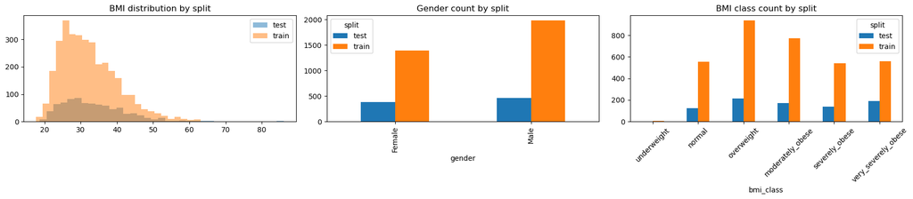

```python
split_summary = (
    df.groupby("split")
    .agg(
        n=("bmi", "size"),
        bmi_mean=("bmi", "mean"),
        bmi_std=("bmi", "std"),
        bmi_min=("bmi", "min"),
        bmi_median=("bmi", "median"),
        bmi_max=("bmi", "max"),
        pairs=("pair_id", "nunique"),
    )
    .round(3)
)
display(split_summary)

fig, axes = plt.subplots(1, 3, figsize=(18, 4))
if sns:
    sns.histplot(data=df, x="bmi", hue="split", bins=35, kde=True, ax=axes[0], element="step")
    sns.countplot(data=df, x="gender", hue="split", ax=axes[1])
    sns.countplot(data=df, x="bmi_class", hue="split", ax=axes[2])
else:
    for split, part in df.groupby("split"):
        axes[0].hist(part["bmi"], bins=35, alpha=0.5, label=split)
    axes[0].legend()
    df.groupby(["gender", "split"]).size().unstack(fill_value=0).plot(kind="bar", ax=axes[1])
    df.groupby(["bmi_class", "split"]).size().unstack(fill_value=0).plot(kind="bar", ax=axes[2])
axes[0].set_title("BMI distribution by split")
axes[1].set_title("Gender count by split")
axes[2].set_title("BMI class count by split")
axes[2].tick_params(axis="x", rotation=45)
plt.tight_layout()
plt.show()
```

## 4. BMI and Gender Distribution

| bmi_class gender | underweight | normal | overweight | moderately_obese | severely_obese | very_severely_obese | All |
| --- | --- | --- | --- | --- | --- | --- | --- |
| Female | 5 | 318 | 428 | 412 | 272 | 333 | 1768 |
| Male | 2 | 362 | 723 | 529 | 409 | 413 | 2438 |
| All | 7 | 680 | 1151 | 941 | 681 | 746 | 4206 |

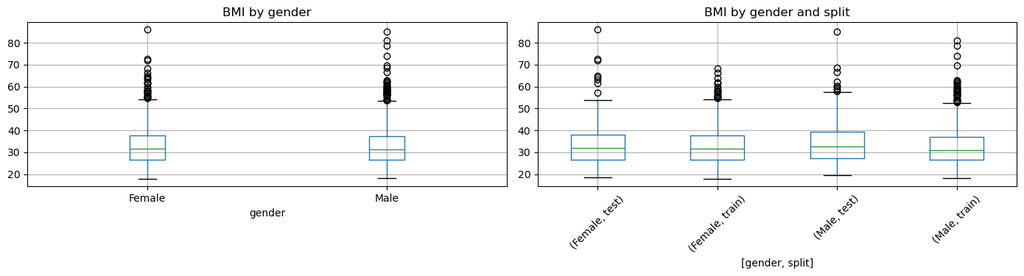

|  | extreme | name | bmi | gender | split | pair_id | pair_position |
| --- | --- | --- | --- | --- | --- | --- | --- |
| 2655 | lowest_bmi | img_2655.bmp | 17.716216 | Female | train | 1327 | second_in_pair |
| 287 | lowest_bmi | img_287.bmp | 17.718967 | Female | train | 143 | second_in_pair |
| 1491 | lowest_bmi | img_1491.bmp | 17.718967 | Female | train | 745 | second_in_pair |
| 1825 | lowest_bmi | img_1825.bmp | 18.129339 | Male | train | 912 | second_in_pair |
| 2631 | lowest_bmi | img_2631.bmp | 18.243945 | Female | train | 1315 | second_in_pair |
| 2491 | lowest_bmi | img_2491.bmp | 18.307292 | Female | train | 1245 | second_in_pair |
| 1767 | lowest_bmi | img_1767.bmp | 18.457257 | Male | train | 883 | second_in_pair |
| 777 | lowest_bmi | img_777.bmp | 18.651020 | Male | train | 388 | second_in_pair |
| 4143 | lowest_bmi | img_4143.bmp | 18.651020 | Female | test | 2071 | second_in_pair |
| 4087 | lowest_bmi | img_4087.bmp | 18.952129 | Female | test | 2043 | second_in_pair |
| 4180 | highest_bmi | img_4180.bmp | 85.987061 | Female | test | 2090 | first_in_pair |
| 4008 | highest_bmi | img_4008.bmp | 84.984889 | Male | test | 2004 | first_in_pair |
| 2156 | highest_bmi | img_2156.bmp | 81.211930 | Male | train | 1078 | first_in_pair |
| 1124 | highest_bmi | img_1124.bmp | 78.908163 | Male | train | 562 | first_in_pair |
| 2132 | highest_bmi | img_2132.bmp | 73.875023 | Male | train | 1066 | first_in_pair |
| 3858 | highest_bmi | img_3858.bmp | 72.604318 | Female | test | 1929 | first_in_pair |
| 4181 | highest_bmi | img_4181.bmp | 72.084961 | Female | test | 2090 | second_in_pair |
| 1586 | highest_bmi | img_1586.bmp | 69.728229 | Male | train | 793 | first_in_pair |
| 3648 | highest_bmi | img_3648.bmp | 68.618441 | Male | test | 1824 | first_in_pair |
| 620 | highest_bmi | img_620.bmp | 68.202902 | Female | train | 310 | first_in_pair |

```python
display(pd.crosstab(df["gender"], df["bmi_class"], margins=True))

fig, axes = plt.subplots(1, 2, figsize=(14, 4))
if sns:
    sns.boxplot(data=df, x="gender", y="bmi", ax=axes[0])
    sns.violinplot(data=df, x="gender", y="bmi", hue="split", split=True, inner="quartile", ax=axes[1])
else:
    df.boxplot(column="bmi", by="gender", ax=axes[0])
    df.boxplot(column="bmi", by=["gender", "split"], ax=axes[1], rot=45)
axes[0].set_title("BMI by gender")
axes[1].set_title("BMI by gender and split")
plt.suptitle("")
plt.tight_layout()
plt.show()

top_extremes = pd.concat([
    df.nsmallest(10, "bmi").assign(extreme="lowest_bmi"),
    df.nlargest(10, "bmi").assign(extreme="highest_bmi"),
])
display(top_extremes[["extreme", "name", "bmi", "gender", "split", "pair_id", "pair_position"]])
```

## 5. Pair and Leakage Checks

The paper data started as before/after pairs. Because this CSV only has one row per face image, this section uses `image_index // 2` as an inferred pair ID and checks whether each pair is kept entirely in train or test.

|  | check | value |
| --- | --- | --- |
| 0 | pairs_total | 2103.000 |
| 1 | pairs_with_not_2_images | 0.000 |
| 2 | pairs_crossing_train_test | 0.000 |
| 3 | pairs_with_mixed_gender | 0.000 |
| 4 | median_abs_bmi_delta_within_pair | 7.754 |
| 5 | max_abs_bmi_delta_within_pair | 43.117 |

| pair_id | n_images | n_splits | splits | n_genders | genders | bmi_min | bmi_max | bmi_mean | bmi_delta |
| --- | --- | --- | --- | --- | --- | --- | --- | --- | --- |
| 2004 | 2 | 1 | test | 1 | Male | 41.868 | 84.985 | 63.426 | 43.117 |
| 1824 | 2 | 1 | test | 1 | Male | 29.292 | 68.618 | 48.955 | 39.327 |
| 1078 | 2 | 1 | train | 1 | Male | 42.083 | 81.212 | 61.647 | 39.129 |
| 310 | 2 | 1 | train | 1 | Female | 36.652 | 68.203 | 52.427 | 31.551 |
| 562 | 2 | 1 | train | 1 | Male | 48.206 | 78.908 | 63.557 | 30.702 |
| 2062 | 2 | 1 | test | 1 | Male | 27.259 | 57.388 | 42.323 | 30.129 |
| 705 | 2 | 1 | train | 1 | Male | 20.173 | 50.030 | 35.102 | 29.857 |
| 837 | 2 | 1 | train | 1 | Male | 28.541 | 57.428 | 42.984 | 28.887 |
| 1707 | 2 | 1 | test | 1 | Male | 30.939 | 59.182 | 45.061 | 28.243 |
| 1811 | 2 | 1 | test | 1 | Female | 34.968 | 63.094 | 49.031 | 28.126 |
| 1030 | 2 | 1 | train | 1 | Male | 34.277 | 62.264 | 48.270 | 27.986 |
| 938 | 2 | 1 | train | 1 | Male | 30.986 | 58.906 | 44.946 | 27.920 |
| 37 | 2 | 1 | train | 1 | Female | 24.028 | 51.489 | 37.759 | 27.461 |
| 442 | 2 | 1 | train | 1 | Female | 22.594 | 50.030 | 36.312 | 27.436 |
| 313 | 2 | 1 | train | 1 | Female | 22.312 | 49.378 | 35.845 | 27.067 |

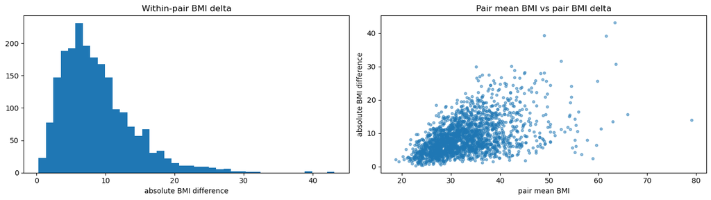

```python
pair_summary = (
    df.groupby("pair_id")
    .agg(
        n_images=("name", "size"),
        n_splits=("split", "nunique"),
        splits=("split", lambda s: ",".join(sorted(s.unique()))),
        n_genders=("gender", "nunique"),
        genders=("gender", lambda s: ",".join(sorted(s.unique()))),
        bmi_min=("bmi", "min"),
        bmi_max=("bmi", "max"),
        bmi_mean=("bmi", "mean"),
    )
    .assign(bmi_delta=lambda x: x["bmi_max"] - x["bmi_min"])
)

pair_checks = pd.DataFrame({
    "check": [
        "pairs_total",
        "pairs_with_not_2_images",
        "pairs_crossing_train_test",
        "pairs_with_mixed_gender",
        "median_abs_bmi_delta_within_pair",
        "max_abs_bmi_delta_within_pair",
    ],
    "value": [
        len(pair_summary),
        int((pair_summary["n_images"] != 2).sum()),
        int((pair_summary["n_splits"] > 1).sum()),
        int((pair_summary["n_genders"] > 1).sum()),
        round(pair_summary["bmi_delta"].median(), 3),
        round(pair_summary["bmi_delta"].max(), 3),
    ],
})
display(pair_checks)

display(pair_summary.sort_values("bmi_delta", ascending=False).head(15).round(3))

fig, axes = plt.subplots(1, 2, figsize=(14, 4))
axes[0].hist(pair_summary["bmi_delta"], bins=40)
axes[0].set_title("Within-pair BMI delta")
axes[0].set_xlabel("absolute BMI difference")
axes[1].scatter(pair_summary["bmi_mean"], pair_summary["bmi_delta"], s=12, alpha=0.5)
axes[1].set_title("Pair mean BMI vs pair BMI delta")
axes[1].set_xlabel("pair mean BMI")
axes[1].set_ylabel("absolute BMI difference")
plt.tight_layout()
plt.show()
```

## 6. Image File Audit

This computes dimensions, brightness, contrast, a simple blur score, exact hashes, and perceptual hashes. It is intentionally lightweight enough to run on all 4,206 images.

```python
def exact_file_md5(path, chunk_size=1024 * 1024):
    h = hashlib.md5()
    with open(path, "rb") as f:
        for chunk in iter(lambda: f.read(chunk_size), b""):
            h.update(chunk)
    return h.hexdigest()


def average_hash(img, hash_size=8):
    gray = ImageOps.grayscale(img).resize((hash_size, hash_size))
    arr = np.asarray(gray, dtype=np.float32)
    bits = arr > arr.mean()
    return "".join("1" if b else "0" for b in bits.flatten())


def blur_score_from_gray(gray_arr):
    gray_arr = gray_arr.astype(np.float32)
    if cv2 is not None:
        return float(cv2.Laplacian(gray_arr, cv2.CV_32F).var())
    dx = np.diff(gray_arr, axis=1)
    dy = np.diff(gray_arr, axis=0)
    return float(dx.var() + dy.var())


def audit_image(row):
    path = row["image_path"]
    record = {
        "name": row["name"],
        "exists": path.exists(),
        "readable": False,
        "width": np.nan,
        "height": np.nan,
        "aspect_ratio": np.nan,
        "mode": None,
        "file_size_kb": np.nan,
        "brightness_mean": np.nan,
        "contrast_std": np.nan,
        "blur_score": np.nan,
        "exact_md5": None,
        "avg_hash": None,
        "error": None,
    }
    if not path.exists():
        record["error"] = "missing_file"
        return record

    try:
        with Image.open(path) as img:
            img.load()
            gray = ImageOps.grayscale(img)
            gray_arr = np.asarray(gray)
            stat = ImageStat.Stat(gray)
            record.update({
                "readable": True,
                "width": img.width,
                "height": img.height,
                "aspect_ratio": img.width / img.height if img.height else np.nan,
                "mode": img.mode,
                "file_size_kb": path.stat().st_size / 1024,
                "brightness_mean": float(stat.mean[0]),
                "contrast_std": float(stat.stddev[0]),
                "blur_score": blur_score_from_gray(gray_arr),
                "exact_md5": exact_file_md5(path),
                "avg_hash": average_hash(img),
            })
    except (UnidentifiedImageError, OSError, ValueError) as exc:
        record["error"] = repr(exc)
    return record


audit_records = [audit_image(row) for _, row in df.iterrows()]
image_audit = pd.DataFrame(audit_records)
eda = df.merge(image_audit, on="name", how="left")

image_audit_path = OUTPUT_DIR / "image_quality_audit.csv"
eda.to_csv(image_audit_path, index=False)
print(f"Saved image audit to: {image_audit_path}")
display(eda.head())
```

```
Saved image audit to: /Users/satanhaha/Documents/MS ADS/ML2/Final Project/Nyssa/Nyssa/eda_outputs/image_quality_audit.csv
```

|  | bmi | gender | is_training | name | image_path | split | image_index | pair_id | pair_position | bmi_class | exists | readable | width | height | aspect_ratio | mode | file_size_kb | brightness_mean | contrast_std | blur_score | exact_md5 | avg_hash | error |
| --- | --- | --- | --- | --- | --- | --- | --- | --- | --- | --- | --- | --- | --- | --- | --- | --- | --- | --- | --- | --- | --- | --- | --- |
| 0 | 34.207396 | Male | 1 | img_0.bmp | /Users/satanhaha/Documents/MS ADS/ML2/Final Pr... | train | 0 | 0 | first_in_pair | moderately_obese | True | True | 164.0 | 176.0 | 0.931818 | RGB | 84.615234 | 130.244422 | 57.141387 | 625.102539 | 6fafc2b62861870943670fbf58ac6ddd | 1110011111011111110111111000000000001111000011... | NaN |
| 1 | 26.453720 | Male | 1 | img_1.bmp | /Users/satanhaha/Documents/MS ADS/ML2/Final Pr... | train | 1 | 0 | second_in_pair | overweight | True | True | 150.0 | 173.0 | 0.867052 | RGB | 76.416016 | 89.709788 | 55.665160 | 185.098190 | b0ef60508eaf09fd83cc5dd2a8201f00 | 0000000011000001110000011100000111000111110001... | NaN |
| 2 | 34.967561 | Female | 1 | img_2.bmp | /Users/satanhaha/Documents/MS ADS/ML2/Final Pr... | train | 2 | 1 | first_in_pair | moderately_obese | True | True | 226.0 | 251.0 | 0.900398 | RGB | 166.732422 | 109.184836 | 59.844535 | 145.398285 | 0a18e182ef96d8639ef44798f9a05460 | 1111111111100011110110010001100100111101001111... | NaN |
| 3 | 22.044766 | Female | 1 | img_3.bmp | /Users/satanhaha/Documents/MS ADS/ML2/Final Pr... | train | 3 | 1 | second_in_pair | normal | True | True | 97.0 | 126.0 | 0.769841 | RGB | 35.982422 | 129.599411 | 43.259079 | 283.950775 | ff8caa558fe10bde2433ee80c18c2d3d | 1000000010011100000111000011111000111110001111... | NaN |
| 4 | 37.758789 | Female | 1 | img_4.bmp | /Users/satanhaha/Documents/MS ADS/ML2/Final Pr... | train | 4 | 2 | first_in_pair | severely_obese | False | False | NaN | NaN | NaN | NaN | NaN | NaN | NaN | NaN | NaN | NaN | missing_file |

|  | count | mean | std | min | 25% | 50% | 75% | max |
| --- | --- | --- | --- | --- | --- | --- | --- | --- |
| width | 3962.0 | 293.395 | 170.873 | 41.000 | 159.000 | 249.000 | 392.000 | 900.000 |
| height | 3962.0 | 364.522 | 221.004 | 52.000 | 193.000 | 306.000 | 482.000 | 1222.000 |
| aspect_ratio | 3962.0 | 0.820 | 0.097 | 0.500 | 0.752 | 0.813 | 0.881 | 1.288 |
| file_size_kb | 3962.0 | 426.359 | 499.627 | 6.350 | 92.391 | 229.557 | 556.951 | 3016.865 |
| brightness_mean | 3962.0 | 112.607 | 26.663 | 27.485 | 94.189 | 112.019 | 130.095 | 222.493 |
| contrast_std | 3962.0 | 55.844 | 13.222 | 15.592 | 46.826 | 55.696 | 65.150 | 95.890 |
| blur_score | 3962.0 | 187.323 | 209.594 | 2.713 | 56.940 | 123.052 | 245.526 | 3329.357 |

```
Unreadable or missing images: 244
```

|  | name | image_path | error |
| --- | --- | --- | --- |
| 4 | img_4.bmp | /Users/satanhaha/Documents/MS ADS/ML2/Final Pr... | missing_file |
| 5 | img_5.bmp | /Users/satanhaha/Documents/MS ADS/ML2/Final Pr... | missing_file |
| 40 | img_40.bmp | /Users/satanhaha/Documents/MS ADS/ML2/Final Pr... | missing_file |
| 86 | img_86.bmp | /Users/satanhaha/Documents/MS ADS/ML2/Final Pr... | missing_file |
| 93 | img_93.bmp | /Users/satanhaha/Documents/MS ADS/ML2/Final Pr... | missing_file |
| 112 | img_112.bmp | /Users/satanhaha/Documents/MS ADS/ML2/Final Pr... | missing_file |
| 113 | img_113.bmp | /Users/satanhaha/Documents/MS ADS/ML2/Final Pr... | missing_file |
| 238 | img_238.bmp | /Users/satanhaha/Documents/MS ADS/ML2/Final Pr... | missing_file |
| 239 | img_239.bmp | /Users/satanhaha/Documents/MS ADS/ML2/Final Pr... | missing_file |
| 300 | img_300.bmp | /Users/satanhaha/Documents/MS ADS/ML2/Final Pr... | missing_file |
| 301 | img_301.bmp | /Users/satanhaha/Documents/MS ADS/ML2/Final Pr... | missing_file |
| 309 | img_309.bmp | /Users/satanhaha/Documents/MS ADS/ML2/Final Pr... | missing_file |
| 436 | img_436.bmp | /Users/satanhaha/Documents/MS ADS/ML2/Final Pr... | missing_file |
| 437 | img_437.bmp | /Users/satanhaha/Documents/MS ADS/ML2/Final Pr... | missing_file |
| 530 | img_530.bmp | /Users/satanhaha/Documents/MS ADS/ML2/Final Pr... | missing_file |
| 531 | img_531.bmp | /Users/satanhaha/Documents/MS ADS/ML2/Final Pr... | missing_file |
| 579 | img_579.bmp | /Users/satanhaha/Documents/MS ADS/ML2/Final Pr... | missing_file |
| 617 | img_617.bmp | /Users/satanhaha/Documents/MS ADS/ML2/Final Pr... | missing_file |
| 670 | img_670.bmp | /Users/satanhaha/Documents/MS ADS/ML2/Final Pr... | missing_file |
| 671 | img_671.bmp | /Users/satanhaha/Documents/MS ADS/ML2/Final Pr... | missing_file |

```
Exact duplicate image groups: 0
Shared average-hash groups, possible near duplicates: 1
```

|  | name | bmi | gender | split | pair_id | exact_md5 |
| --- | --- | --- | --- | --- | --- | --- |

|  | name | bmi | gender | split | pair_id | avg_hash |
| --- | --- | --- | --- | --- | --- | --- |
| 1592 | img_1592.bmp | 32.383002 | Female | train | 796 | 0000000000011100001111100111111001111110001111... |
| 4125 | img_4125.bmp | 27.259184 | Male | test | 2062 | 0000000000011100001111100111111001111110001111... |

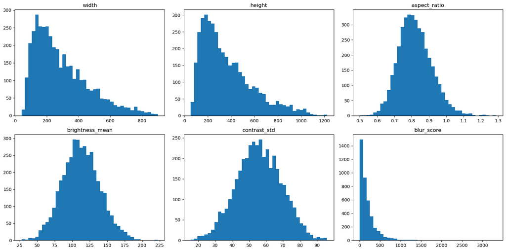

```python
quality_summary = eda[[
    "width", "height", "aspect_ratio", "file_size_kb", "brightness_mean", "contrast_std", "blur_score"
]].describe().T.round(3)
display(quality_summary)

bad_images = eda.loc[~eda["readable"].fillna(False), ["name", "image_path", "error"]]
print(f"Unreadable or missing images: {len(bad_images):,}")
display(bad_images.head(20))

exact_duplicates = eda[eda["exact_md5"].notna() & eda.duplicated("exact_md5", keep=False)].sort_values("exact_md5")
near_duplicates = eda[eda["avg_hash"].notna() & eda.duplicated("avg_hash", keep=False)].sort_values("avg_hash")
print(f"Exact duplicate image groups: {exact_duplicates['exact_md5'].nunique():,}")
print(f"Shared average-hash groups, possible near duplicates: {near_duplicates['avg_hash'].nunique():,}")
display(exact_duplicates[["name", "bmi", "gender", "split", "pair_id", "exact_md5"]].head(30))
display(near_duplicates[["name", "bmi", "gender", "split", "pair_id", "avg_hash"]].head(30))

fig, axes = plt.subplots(2, 3, figsize=(16, 8))
cols = ["width", "height", "aspect_ratio", "brightness_mean", "contrast_std", "blur_score"]
for ax, col in zip(axes.ravel(), cols):
    ax.hist(eda[col].dropna(), bins=40)
    ax.set_title(col)
plt.tight_layout()
plt.show()
```

## 7. Visual Sample Grids

[figure not shown]

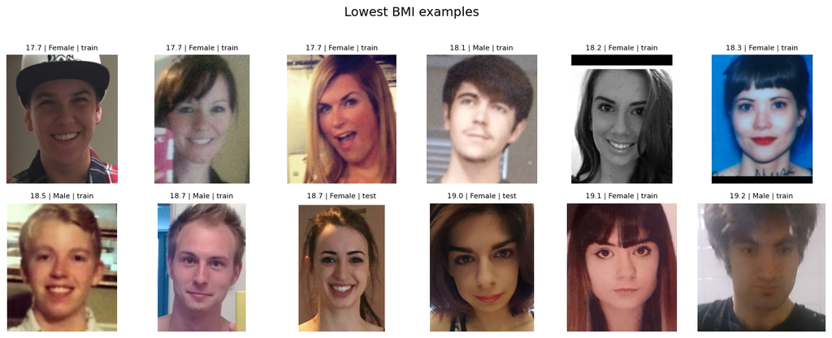

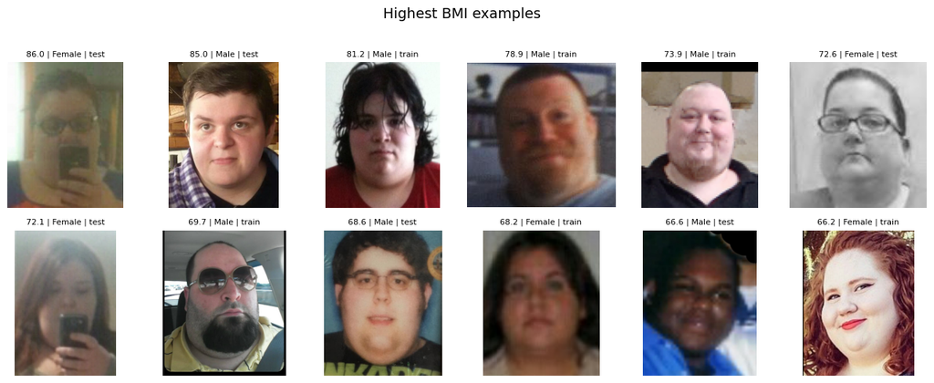

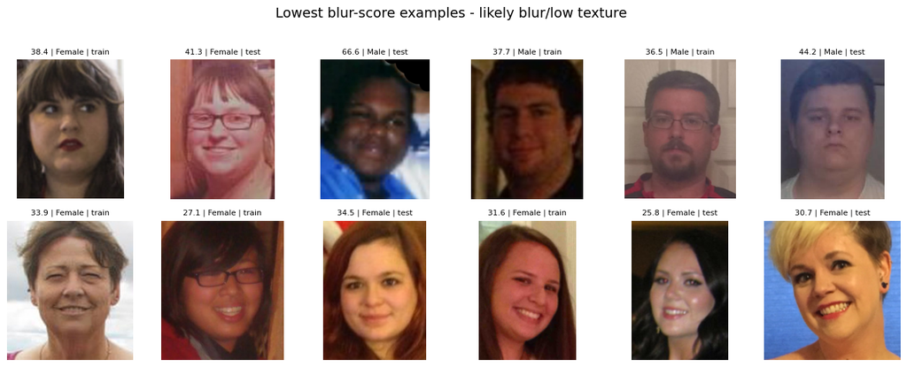

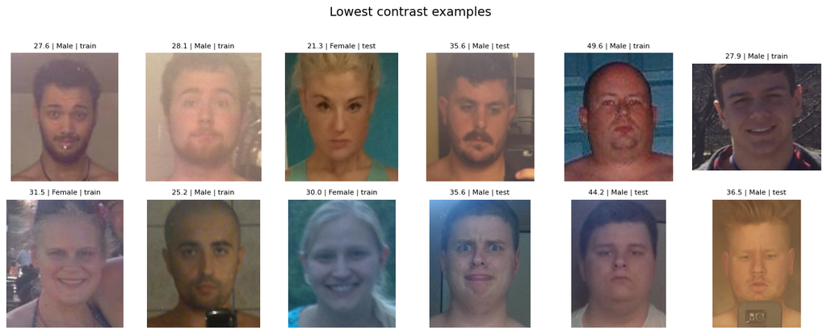

```python
def show_image_grid(rows, title, ncols=6, image_size=2.2):
    rows = rows.reset_index(drop=True)
    if len(rows) == 0:
        print(f"No rows for: {title}")
        return
    ncols = min(ncols, len(rows))
    nrows = math.ceil(len(rows) / ncols)
    fig, axes = plt.subplots(nrows, ncols, figsize=(ncols * image_size, nrows * (image_size + 0.35)))
    axes = np.array(axes).reshape(-1)
    for ax in axes:
        ax.axis("off")
    for ax, (_, row) in zip(axes, rows.iterrows()):
        try:
            img = Image.open(row["image_path"]).convert("RGB")
            ax.imshow(img)
            ax.set_title(f"{row['bmi']:.1f} | {row['gender']} | {row['split']}", fontsize=8)
        except Exception as exc:
            ax.set_title(f"error: {exc}", fontsize=8)
    fig.suptitle(title, y=1.02, fontsize=14)
    plt.tight_layout()
    plt.show()


sampled = (
    eda.groupby(["bmi_class", "gender"], observed=False, group_keys=False)
    .apply(lambda x: x.sample(min(len(x), 3), random_state=42))
    .reset_index(drop=True)
)
show_image_grid(sampled, "Random samples by BMI class and gender", ncols=6)

show_image_grid(eda.nsmallest(12, "bmi"), "Lowest BMI examples", ncols=6)
show_image_grid(eda.nlargest(12, "bmi"), "Highest BMI examples", ncols=6)
show_image_grid(eda.nsmallest(12, "blur_score"), "Lowest blur-score examples - likely blur/low texture", ncols=6)
show_image_grid(eda.nsmallest(12, "contrast_std"), "Lowest contrast examples", ncols=6)
```

## 8. Simple Test-Set Baselines

These are not image models; they are sanity checks. Any pretrained-feature model should beat these. The paper metric is Pearson correlation, but mean-only baselines have undefined/near-zero correlation because their predictions are constant or almost constant.

```python
def pearson_r(y_true, y_pred):
    y_true = np.asarray(y_true, dtype=float)
    y_pred = np.asarray(y_pred, dtype=float)
    if len(y_true) < 2 or np.nanstd(y_true) == 0 or np.nanstd(y_pred) == 0:
        return np.nan
    return float(np.corrcoef(y_true, y_pred)[0, 1])


def regression_metrics(y_true, y_pred):
    y_true = np.asarray(y_true, dtype=float)
    y_pred = np.asarray(y_pred, dtype=float)
    err = y_pred - y_true
    return {
        "n": len(y_true),
        "mae": float(np.mean(np.abs(err))),
        "rmse": float(np.sqrt(np.mean(err ** 2))),
        "pearson_r": pearson_r(y_true, y_pred),
    }


train = eda[eda["split"] == "train"].copy()
test = eda[eda["split"] == "test"].copy()

global_mean = train["bmi"].mean()
gender_means = train.groupby("gender")["bmi"].mean().to_dict()
train_bmi_by_class = train.groupby("bmi_class", observed=False)["bmi"].mean().to_dict()

baseline_preds = pd.DataFrame({
    "actual_bmi": test["bmi"].values,
    "gender": test["gender"].values,
    "bmi_class": test["bmi_class"].astype(str).values,
    "pred_global_train_mean": global_mean,
    "pred_gender_train_mean": test["gender"].map(gender_means).fillna(global_mean).values,
})

metrics = []
for pred_col in ["pred_global_train_mean", "pred_gender_train_mean"]:
    metrics.append({"model": pred_col, "group": "overall", **regression_metrics(baseline_preds["actual_bmi"], baseline_preds[pred_col])})
    for gender, part in baseline_preds.groupby("gender"):
        metrics.append({"model": pred_col, "group": gender, **regression_metrics(part["actual_bmi"], part[pred_col])})

baseline_metrics = pd.DataFrame(metrics).round(4)
display(baseline_metrics)
display(pd.Series(BENCHMARKS, name="paper_target_pearson_r").to_frame())
```

|  | model | group | n | mae | rmse | pearson_r |
| --- | --- | --- | --- | --- | --- | --- |
| 0 | pred_global_train_mean | overall | 838 | 7.0115 | 9.2576 | -0.0000 |
| 1 | pred_global_train_mean | Female | 378 | 6.9906 | 9.3565 | 0.0000 |
| 2 | pred_global_train_mean | Male | 460 | 7.0288 | 9.1755 | -0.0000 |
| 3 | pred_gender_train_mean | overall | 838 | 7.0195 | 9.2661 | -0.0547 |
| 4 | pred_gender_train_mean | Female | 378 | 7.0058 | 9.3426 | -0.0000 |
| 5 | pred_gender_train_mean | Male | 460 | 7.0307 | 9.2028 | NaN |

|  | paper_target_pearson_r |
| --- | --- |
| VGG-Net overall Pearson r | 0.47 |
| VGG-Face male Pearson r | 0.71 |
| VGG-Face female Pearson r | 0.57 |
| VGG-Face overall Pearson r | 0.65 |

## 10. EDA Red-Flag Summary

```python
red_flags = {
    "missing_or_unreadable_images": int((~eda["readable"].fillna(False)).sum()),
    "duplicate_names": int(df.duplicated("name").sum()),
    "exact_duplicate_images": int(exact_duplicates["exact_md5"].nunique()),
    "possible_near_duplicate_hash_groups": int(near_duplicates["avg_hash"].nunique()),
    "pairs_crossing_train_test": int((pair_summary["n_splits"] > 1).sum()),
    "pairs_with_not_2_images": int((pair_summary["n_images"] != 2).sum()),
    "pairs_with_mixed_gender": int((pair_summary["n_genders"] > 1).sum()),
    "underweight_rows": int((eda["bmi_class"] == "underweight").sum()),
    "very_high_bmi_rows_above_60": int((eda["bmi"] > 60).sum()),
}

if "face_count" in eda.columns and eda["face_count"].notna().any():
    red_flags["opencv_flagged_face_crops"] = int(((eda["face_count"] != 1) | (eda["largest_face_area_frac"] < 0.05)).sum())

red_flag_df = pd.Series(red_flags, name="count").to_frame()
display(red_flag_df)

print("Recommended next modeling report columns:")
print("model, pretrained_source, frozen_or_finetuned, input_size, split, n, MAE, RMSE, Pearson r overall, Pearson r male, Pearson r female")
print("Primary comparison target: beat VGG-Face overall Pearson r = 0.65 on the provided test split.")
```

|  | count |
| --- | --- |
| missing_or_unreadable_images | 244 |
| duplicate_names | 0 |
| exact_duplicate_images | 0 |
| possible_near_duplicate_hash_groups | 1 |
| pairs_crossing_train_test | 0 |
| pairs_with_not_2_images | 0 |
| pairs_with_mixed_gender | 0 |
| underweight_rows | 7 |
| very_high_bmi_rows_above_60 | 30 |

```
Recommended next modeling report columns:
model, pretrained_source, frozen_or_finetuned, input_size, split, n, MAE, RMSE, Pearson r overall, Pearson r male, Pearson r female
Primary comparison target: beat VGG-Face overall Pearson r = 0.65 on the provided test split.
```